# Logistic regression

In this tutorial I will explain how you can build a logistic regression model and test it. First we’ll load a data set. It comes from [Kaggle](https://www.kaggle.com/joniarroba/noshowappointments). The data set is compressed and we are going to read directly from the zip file (otherwise it would take too long: 4 versus 24MB).

```r
temp <- tempfile()
download.file("https://github.com/minorsmart/FEB2017/blob/master/Witek/doctor/No-show-Issue-Comma-300k.csv.zip?raw=true",temp)
data <- read.csv(unz(temp, "No-show-Issue-Comma-300k.csv"))
unlink(temp)
```

Now we have the data set in a data frame we can start preparing it for the model. We’ll first load some usefull packages and then look at the structure and quality of the data.

```r
library(dplyr)
library(tidyr)
library(magrittr)
library(caTools)
library(biglm)
library(caret)
```

[output not shown]

```r
str(data)
```

```
'data.frame':   300000 obs. of  15 variables:
 $ Age                    : int  19 24 4 5 38 5 46 4 20 51 ...
 $ Gender                 : Factor w/ 2 levels "F","M": 2 1 1 2 2 1 1 1 1 1 ...
 $ AppointmentRegistration: Factor w/ 295425 levels "2013-05-29T15:14:11Z",..: 152112 248200 23071 87268 274612 71585 225305 244749 125184 70354 ...
 $ ApointmentData         : Factor w/ 534 levels "2014-01-02T00:00:00Z",..: 290 440 36 164 490 152 408 442 232 125 ...
 $ DayOfTheWeek           : Factor w/ 7 levels "Friday","Monday",..: 7 7 6 5 6 6 6 1 6 6 ...
 $ Status                 : Factor w/ 2 levels "No-Show","Show-Up": 2 2 2 2 2 1 2 2 2 2 ...
 $ Diabetes               : int  0 0 0 0 0 0 0 0 0 1 ...
 $ Alcoolism              : int  0 0 0 0 0 0 0 0 0 0 ...
 $ HiperTension           : int  0 0 0 0 0 0 0 0 0 1 ...
 $ Handcap                : int  0 0 0 0 0 0 0 0 0 0 ...
 $ Smokes                 : int  0 0 0 0 0 0 0 0 0 0 ...
 $ Scholarship            : int  0 0 0 0 0 0 0 1 0 0 ...
 $ Tuberculosis           : int  0 0 0 0 0 0 0 0 0 0 ...
 $ Sms_Reminder           : int  0 0 0 1 1 1 1 1 0 1 ...
 $ AwaitingTime           : int  -29 -1 -1 -15 -6 -35 -18 -14 -14 -4 ...
```

```r
summary(data)
```

```
      Age         Gender             AppointmentRegistration              ApointmentData
 Min.   : -2.00   F:200505   2015-04-15T14:19:34Z:     9     2014-10-22T00:00:00Z:   759
 1st Qu.: 19.00   M: 99495   2014-03-19T17:10:21Z:     8     2014-09-03T00:00:00Z:   756
 Median : 38.00              2014-07-03T08:50:50Z:     8     2014-11-24T00:00:00Z:   752
 Mean   : 37.81              2015-05-27T13:57:09Z:     8     2014-11-19T00:00:00Z:   742
 3rd Qu.: 56.00              2013-12-23T12:40:00Z:     7     2015-05-25T00:00:00Z:   741
 Max.   :113.00              2014-01-07T15:42:57Z:     7     2014-09-29T00:00:00Z:   739
                             (Other)             :299953     (Other)             :295511
    DayOfTheWeek       Status          Diabetes         Alcoolism        HiperTension       Handcap
 Friday   :52771   No-Show: 90731   Min.   :0.00000   Min.   :0.00000   Min.   :0.0000   Min.   :0.00000
 Monday   :59298   Show-Up:209269   1st Qu.:0.00000   1st Qu.:0.00000   1st Qu.:0.0000   1st Qu.:0.00000
 Saturday : 1393                    Median :0.00000   Median :0.00000   Median :0.0000   Median :0.00000
 Sunday   :    6                    Mean   :0.07797   Mean   :0.02501   Mean   :0.2159   Mean   :0.02052
 Thursday :60262                    3rd Qu.:0.00000   3rd Qu.:0.00000   3rd Qu.:0.0000   3rd Qu.:0.00000
 Tuesday  :62775                    Max.   :1.00000   Max.   :1.00000   Max.   :1.0000   Max.   :4.00000
 Wednesday:63495
     Smokes         Scholarship      Tuberculosis      Sms_Reminder     AwaitingTime
 Min.   :0.00000   Min.   :0.0000   Min.   :0.00000   Min.   :0.0000   Min.   :-398.00
 1st Qu.:0.00000   1st Qu.:0.0000   1st Qu.:0.00000   1st Qu.:0.0000   1st Qu.: -20.00
 Median :0.00000   Median :0.0000   Median :0.00000   Median :1.0000   Median :  -8.00
 Mean   :0.05237   Mean   :0.0969   Mean   :0.00045   Mean   :0.5742   Mean   : -13.84
 3rd Qu.:0.00000   3rd Qu.:0.0000   3rd Qu.:0.00000   3rd Qu.:1.0000   3rd Qu.:  -4.00
 Max.   :1.00000   Max.   :1.0000   Max.   :1.00000   Max.   :2.0000   Max.   :  -1.00
```

The data set comprises 300,000 recorded doctor’s appointments with 15 variables. We have a lot of categorical variables of which many are boolean (0 or 1). We want to predict whether a patient will show up for a doctor’s appointment (variable `Status`).

We see some peculiar ages like 113 and -2 years. We’ll filter out all ages below 5 and above 95.

Next we will change the `Status` variable into a **0**/**1** boolean. This will help us interpret the predicted value at the end when doing a logistic regression.

Finally we will change all boolean variables into factors and do a visual inspection of the data.

```r
data <- data[,-3]
data <- separate(data, ApointmentData, c("Date", "Time"), sep = "T")
data <- separate(data, Date, c("Year", "Month", "Day"), sep = "-")
data$Year <- as.factor(data$Year)
data <- data[,-6]
data <- filter(data, Age > 5, Age < 95)
data$Status <- (data$Status == "Show-Up")*1
cols <- names(data[4:15])
data %<>% mutate_each_(funs(factor(.)),cols)
str(data)
```

```
'data.frame':   272070 obs. of  16 variables:
 $ Age         : int  19 24 38 46 20 51 33 58 62 62 ...
 $ Gender      : Factor w/ 2 levels "F","M": 2 1 2 1 1 1 2 1 1 1 ...
 $ Year        : Factor w/ 2 levels "2014","2015": 2 2 2 2 1 1 2 1 1 1 ...
 $ Month       : Factor w/ 12 levels "01","02","03",..: 1 8 10 7 10 6 11 5 8 7 ...
 $ Day         : Factor w/ 31 levels "01","02","03",..: 14 19 27 7 28 17 9 22 11 14 ...
 $ DayOfTheWeek: Factor w/ 7 levels "Friday","Monday",..: 7 7 6 6 6 6 2 5 2 2 ...
 $ Status      : Factor w/ 2 levels "0","1": 2 2 2 2 2 2 2 2 1 2 ...
 $ Diabetes    : Factor w/ 2 levels "0","1": 1 1 1 1 1 2 1 1 2 1 ...
 $ Alcoolism   : Factor w/ 2 levels "0","1": 1 1 1 1 1 1 1 1 1 1 ...
 $ HiperTension: Factor w/ 2 levels "0","1": 1 1 1 1 1 2 1 2 2 1 ...
 $ Handcap     : Factor w/ 5 levels "0","1","2","3",..: 1 1 1 1 1 1 1 1 1 1 ...
 $ Smokes      : Factor w/ 2 levels "0","1": 1 1 1 1 1 1 1 1 1 1 ...
 $ Scholarship : Factor w/ 2 levels "0","1": 1 1 1 1 1 1 1 2 1 1 ...
 $ Tuberculosis: Factor w/ 2 levels "0","1": 1 1 1 1 1 1 1 1 1 1 ...
 $ Sms_Reminder: Factor w/ 3 levels "0","1","2": 1 1 2 2 1 2 1 2 1 2 ...
 $ AwaitingTime: int  -29 -1 -6 -18 -14 -4 -39 -22 -17 -6 ...
```

```r
summary(data)
```

```
      Age        Gender       Year            Month             Day            DayOfTheWeek   Status
 Min.   : 6.00   F:186972   2014:139462   07     : 24847   10     : 10922   Friday   :48050   0: 81684
 1st Qu.:24.00   M: 85098   2015:132608   10     : 24679   17     : 10005   Monday   :53796   1:190386
 Median :42.00                            05     : 23606   09     :  9981   Saturday : 1352
 Mean   :41.41                            08     : 23547   24     :  9909   Sunday   :    6
 3rd Qu.:57.00                            09     : 23430   14     :  9745   Thursday :54259
 Max.   :94.00                            06     : 23217   16     :  9702   Tuesday  :57042
                                          (Other):128744   (Other):211806   Wednesday:57565
 Diabetes   Alcoolism  HiperTension Handcap    Smokes     Scholarship Tuberculosis Sms_Reminder
 0:248732   0:264576   0:207456     0:266572   0:256366   0:245217    0:271940     0:116897
 1: 23338   1:  7494   1: 64614     1:  5023   1: 15704   1: 26853    1:   130     1:154437
                                    2:   435                                       2:   736
                                    3:    34
                                    4:     6


  AwaitingTime
 Min.   :-398.0
 1st Qu.: -20.0
 Median :  -8.0
 Mean   : -13.7
 3rd Qu.:  -4.0
 Max.   :  -1.0
```

[figure not shown]

```r
barplot(sum(is.na(data)*1)/dim(data)[1])
```

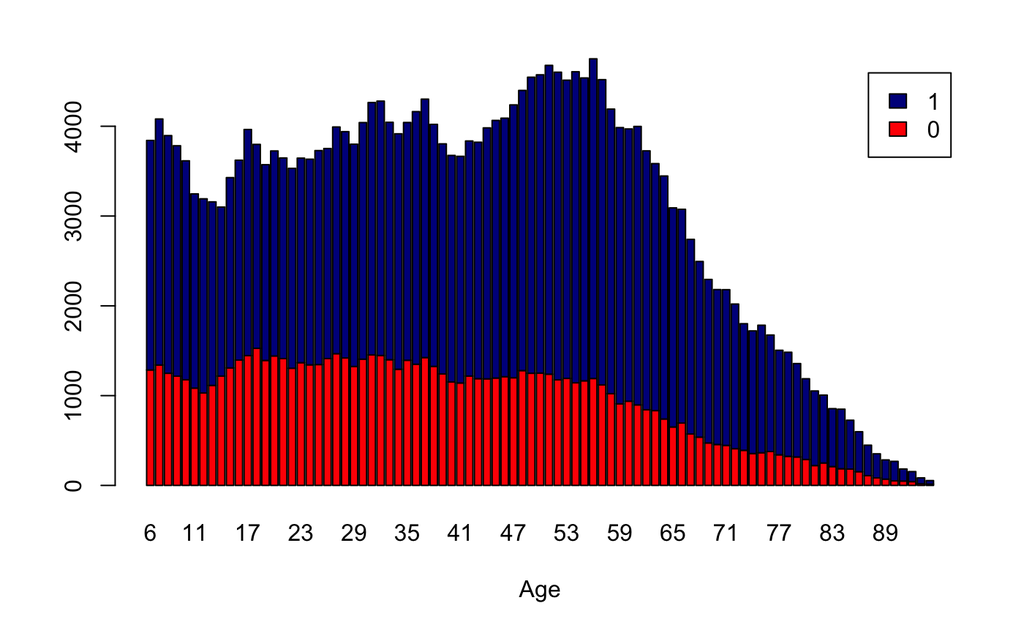

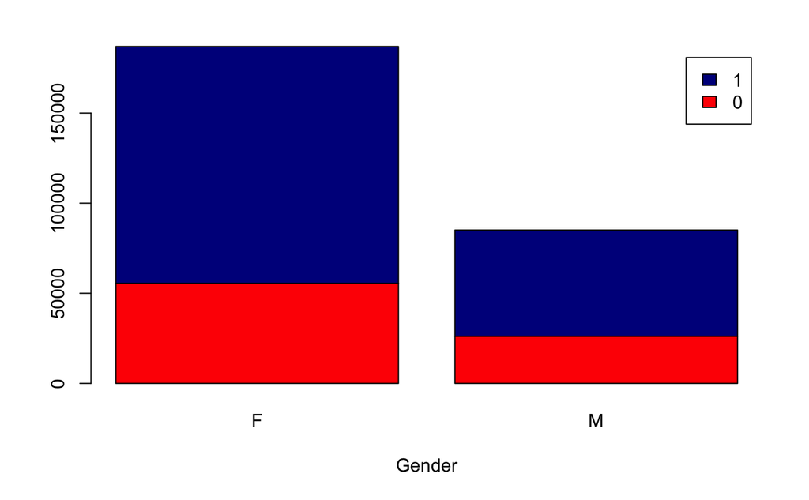

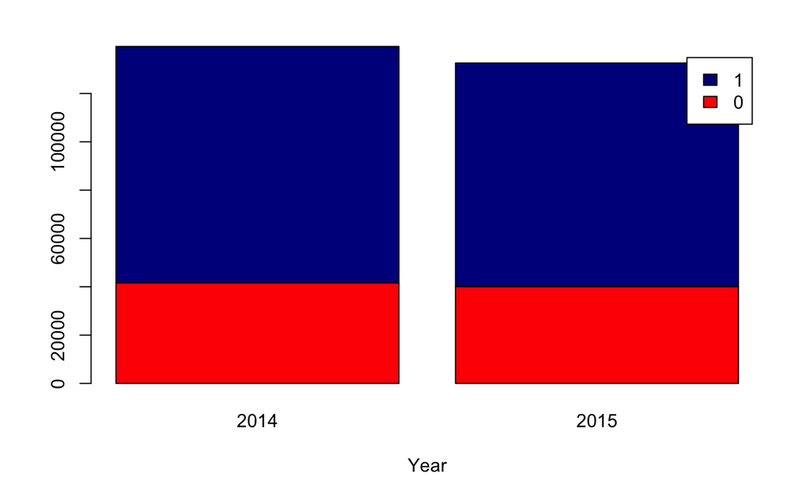

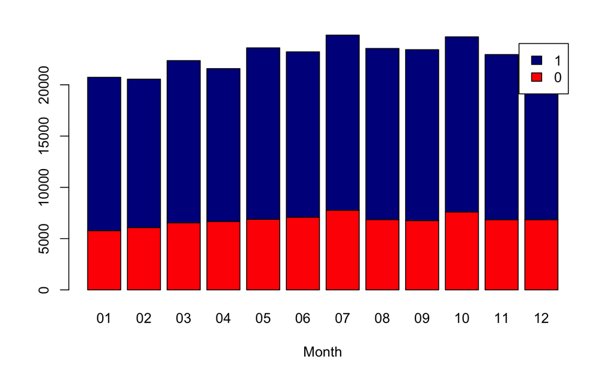

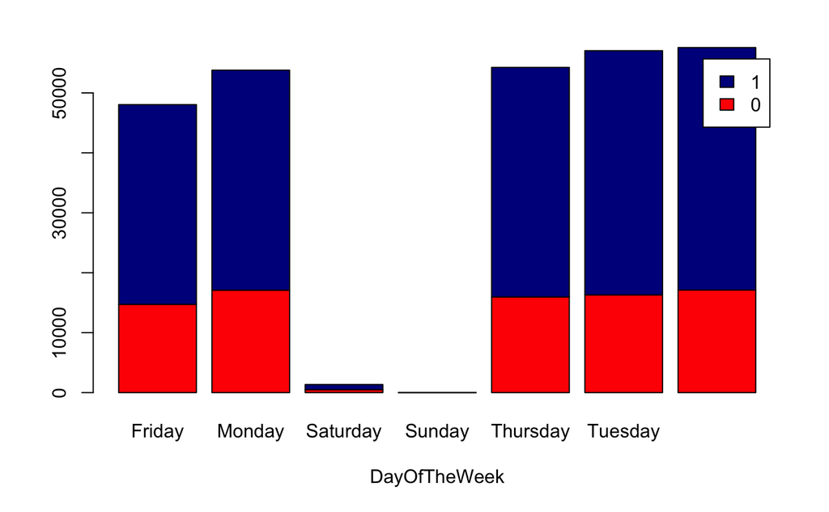

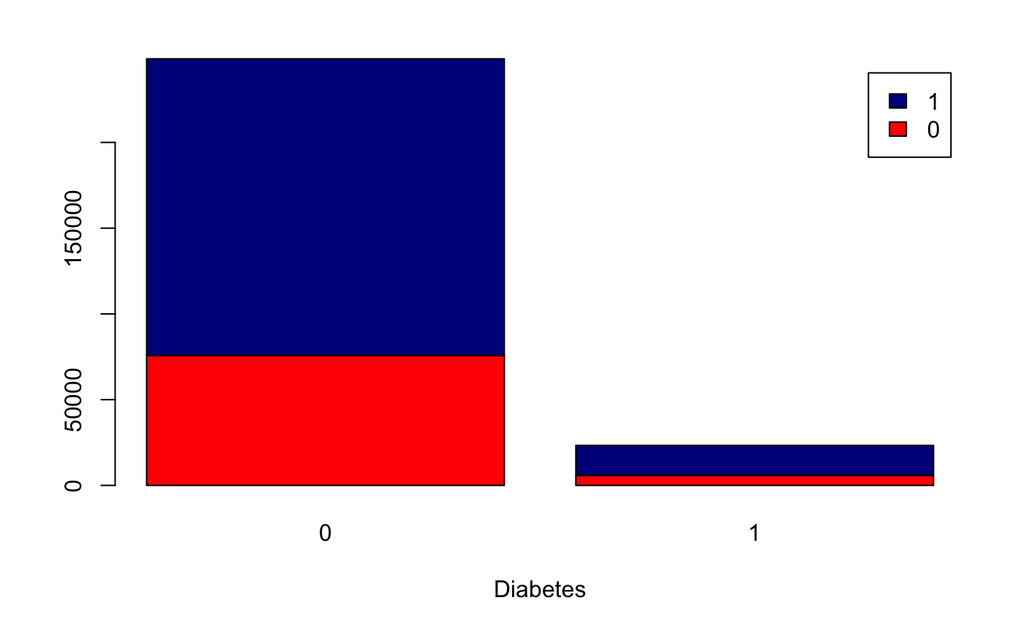

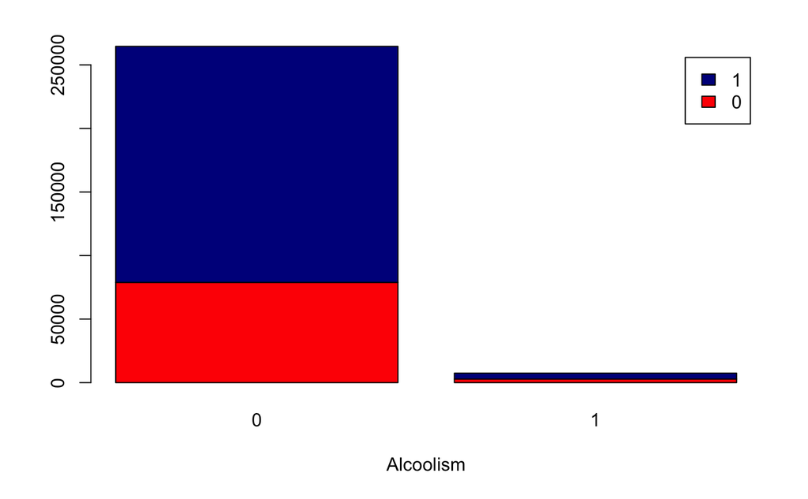

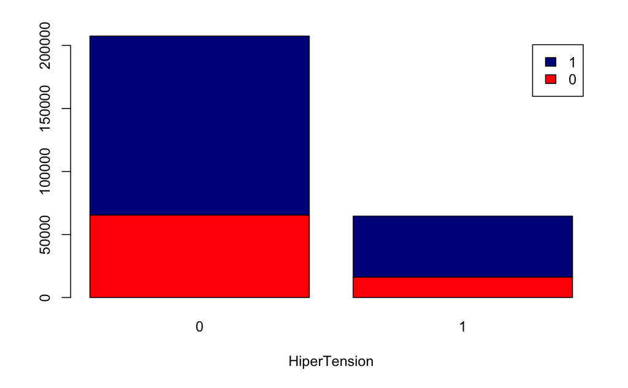

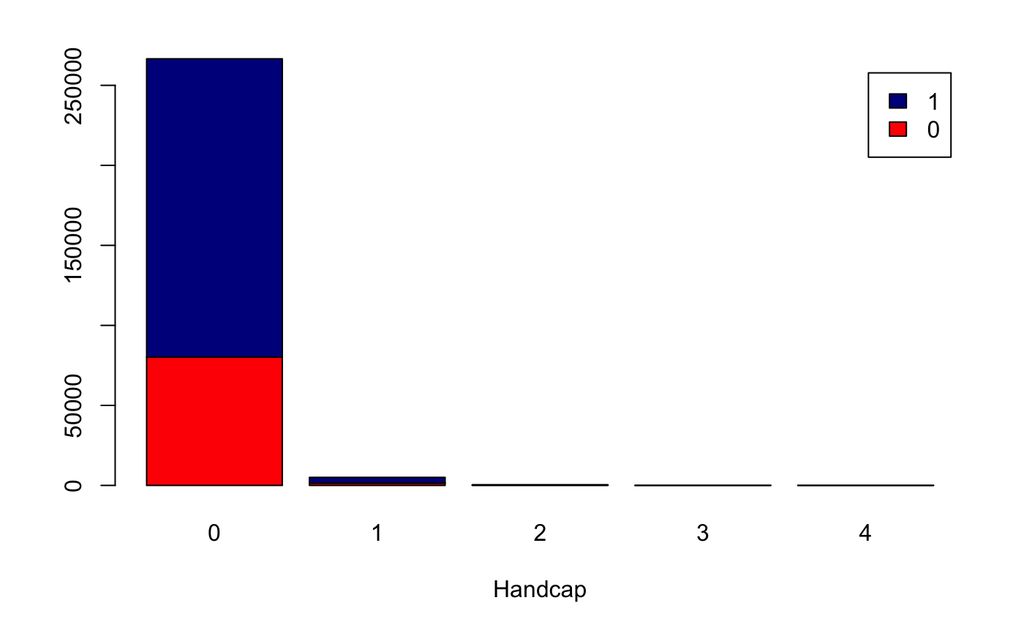

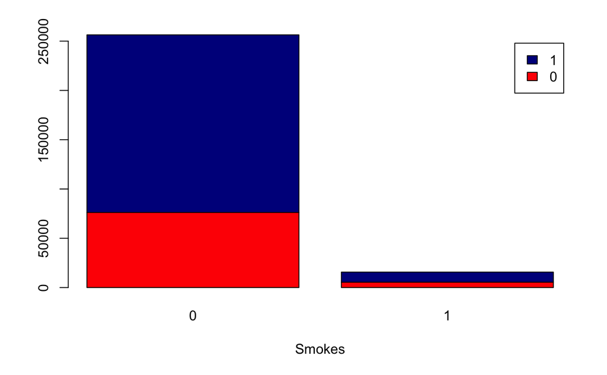

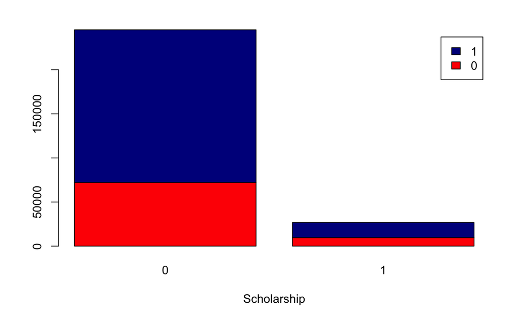

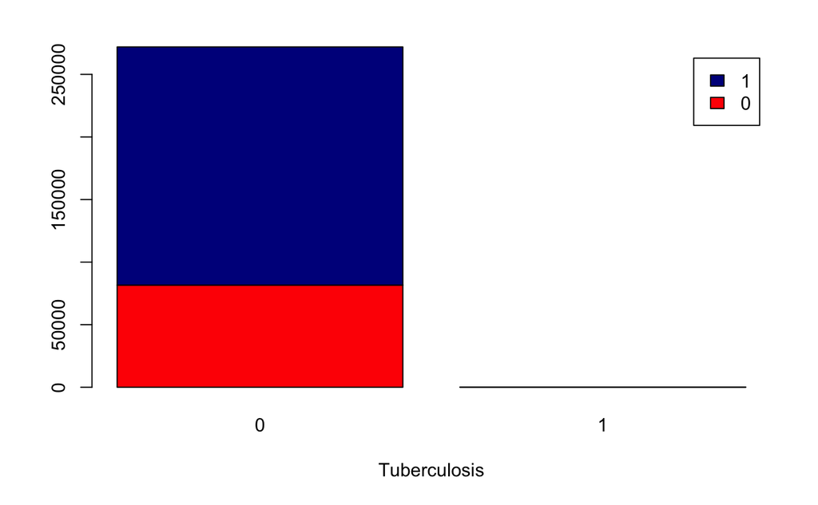

[2 more figures not shown]

```r
selCols <- c("Age", "Gender", "Year", "Month", "DayOfTheWeek", "Diabetes", "Alcoolism", "HiperTension", "Handcap", "Smokes", "Scholarship", "Tuberculosis", "Sms_Reminder", "AwaitingTime")
for(i in selCols) {

  counts <- table(data$Status, data[, i])
  barplot(counts, col=c("red","darkblue"), xlab = i, legend = rownames(counts))

}
```

```r
NA
```

```r
data$spl <- sample.split(data$Status, SplitRatio=0.70)
train <- subset(data, data$spl==TRUE)
test <- subset(data, data$spl==FALSE)
```

Now we can train a model using a logistic regression and have a look at the parameters.

```r
reg.model <- glm (Status ~ . -spl, data = train, family = binomial)
summary(reg.model)
```

```
Call:
glm(formula = Status ~ . - spl, family = binomial, data = train)

Deviance Residuals:
    Min       1Q   Median       3Q      Max
-1.9676  -1.3898   0.7560   0.8718   2.3050

Coefficients:
                        Estimate Std. Error z value Pr(>|z|)
(Intercept)            0.5609091  0.0416755  13.459  < 2e-16 ***
Age                    0.0119706  0.0002943  40.672  < 2e-16 ***
GenderM               -0.0216609  0.0110916  -1.953  0.05083 .
Year2015              -0.0201924  0.0102738  -1.965  0.04936 *
Month02               -0.1202732  0.0267946  -4.489 7.17e-06 ***
Month03               -0.0806014  0.0262810  -3.067  0.00216 **
Month04               -0.1485641  0.0262134  -5.667 1.45e-08 ***
Month05               -0.0598902  0.0256415  -2.336  0.01951 *
Month06               -0.1111399  0.0259940  -4.276 1.91e-05 ***
Month07               -0.1612490  0.0251920  -6.401 1.55e-10 ***
Month08               -0.0560830  0.0259257  -2.163  0.03052 *
Month09               -0.0448688  0.0261151  -1.718  0.08578 .
Month10               -0.1147210  0.0252488  -4.544 5.53e-06 ***
Month11               -0.0713707  0.0262503  -2.719  0.00655 **
Month12               -0.2633343  0.0264240  -9.966  < 2e-16 ***
Day02                  0.0351254  0.0428283   0.820  0.41213
Day03                  0.0095578  0.0419918   0.228  0.81995
Day04                  0.0797694  0.0435459   1.832  0.06697 .
Day05                  0.0783902  0.0442724   1.771  0.07662 .
Day06                 -0.0648963  0.0422072  -1.538  0.12415
Day07                  0.0128978  0.0426370   0.303  0.76227
Day08                 -0.0318983  0.0437601  -0.729  0.46604
Day09                  0.0247753  0.0412723   0.600  0.54831
Day10                  0.0109201  0.0406658   0.269  0.78829
Day11                  0.0403618  0.0420872   0.959  0.33756
Day12                  0.0709767  0.0437583   1.622  0.10480
Day13                  0.0827147  0.0431609   1.916  0.05531 .
Day14                  0.0536390  0.0416005   1.289  0.19726
Day15                 -0.0137989  0.0416458  -0.331  0.74039
Day16                  0.1265090  0.0418264   3.025  0.00249 **
Day17                  0.0489550  0.0414607   1.181  0.23770
```

[output cut: 28 more lines]

```
Scholarship1          -0.1800135  0.0166321 -10.823  < 2e-16 ***
Tuberculosis1         -0.1715891  0.2141520  -0.801  0.42299
Sms_Reminder1          0.1054209  0.0110856   9.510  < 2e-16 ***
Sms_Reminder2          0.0039772  0.0976678   0.041  0.96752
AwaitingTime           0.0102560  0.0003296  31.115  < 2e-16 ***
---
Signif. codes:  0 ‘***’ 0.001 ‘**’ 0.01 ‘*’ 0.05 ‘.’ 0.1 ‘ ’ 1

(Dispersion parameter for binomial family taken to be 1)

    Null deviance: 232752  on 190448  degrees of freedom
Residual deviance: 228520  on 190385  degrees of freedom
AIC: 228648

Number of Fisher Scoring iterations: 4
```

We can test how well the model performs by comparing its predictions with actual values. The model returns a likelihood value. We set the cutoff rate at a = 0.5.

```r
a <- 0.5
test$predict <- predict(reg.model, newdata=test, type='response')
test$predictb <- ifelse(test$predict > a,1,0)
misClasificError <- mean(test$predictb != test$Status)
print(paste('Accuracy',1-misClasificError))
```

```
[1] "Accuracy 0.699268570588451"
```

```r
cfnMat <- confusionMatrix(test$predictb, test$Status)
print(cfnMat)
```

```
Confusion Matrix and Statistics

          Reference
Prediction     0     1
         0   189   230
         1 24316 56886

               Accuracy : 0.6993
                 95% CI : (0.6961, 0.7024)
    No Information Rate : 0.6998
    P-Value [Acc > NIR] : 0.6245

                  Kappa : 0.0051
 Mcnemar's Test P-Value : <2e-16

            Sensitivity : 0.007713
            Specificity : 0.995973
         Pos Pred Value : 0.451074
         Neg Pred Value : 0.700549
             Prevalence : 0.300229
         Detection Rate : 0.002316
   Detection Prevalence : 0.005133
      Balanced Accuracy : 0.501843

       'Positive' Class : 0
```

The No Information Rate is equal to the mean of the status variable. So, if we would have build a model that would generate a **1** regardless of any input information it would have an accuracy of 70%, which is almost equal to the accuracy of the logistic model.

Apparently the process underlying the meeting of doctor’s appointments is not linearly logistic (at least not by this model). We should try a different approach like decision trees or neural networks.

First we’ll try a simple tree model to see whether that improves accuracy. We’ll use the `rpart` package for this. After that we will try and see how an basic neural network performs on the data.

```r
library(rpart)
tree.model <- rpart(Status ~ . -spl, data = train, method = 'class', minsplit = 2, minbucket = 1)
summary(tree.model)
```

```
Call:
rpart(formula = Status ~ . - spl, data = train, method = "class",
    minsplit = 2, minbucket = 1)
  n= 190449

  CP nsplit rel error xerror xstd
1  0      0         1      0    0

Node number 1: 190449 observations
  predicted class=1  expected loss=0.3002326  P(node) =1
    class counts: 57179 133270
   probabilities: 0.300 0.700
```

```r
bestcp <- tree.model$cptable[which.min(tree.model$cptable[,"xerror"]),"CP"]
tree.pruned <- prune(tree.model, cp = bestcp)
library(rattle)
library(rpart.plot)
library(RColorBrewer)
fancyRpartPlot(tree.model)
```

[output not shown]

```r
library(nnet)
train$Status <- as.factor(train$Status)
nn.model <- nnet(Status ~ . -spl, data=train, size=10, maxit=600)
library(devtools)
source_url('https://gist.githubusercontent.com/fawda123/7471137/raw/466c1474d0a505ff044412703516c34f1a4684a5/nnet_plot_update.r')
```

```
SHA-1 hash of file is 74c80bd5ddbc17ab3ae5ece9c0ed9beb612e87ef
```

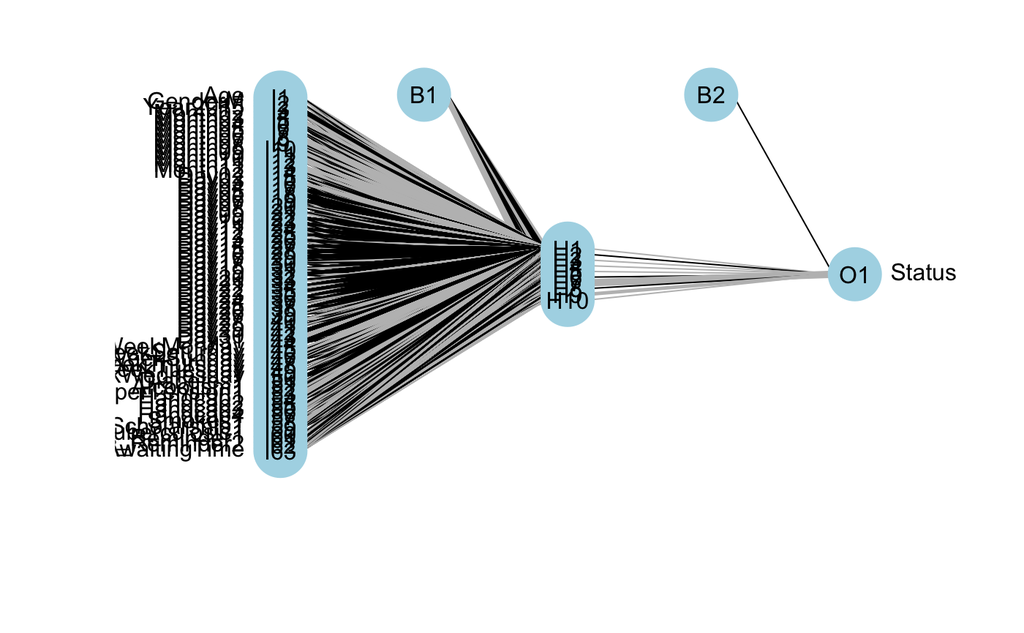

```r
#plot the model
plot.nnet(nn.model)
```

```r
test$predict <- NULL
test$predictb <- NULL
test$Status <- as.factor(test$Status)
test$predict <- predict(nn.model, newdata=test, type='class')
misClasificError <- mean(test$predict != test$Status)
print(paste('Accuracy',1-misClasificError))
```

```
[1] "Accuracy 0.702245745580182"
```

```r
cfnMat <- confusionMatrix(test$predict, test$Status)
print(cfnMat)
```

```
Confusion Matrix and Statistics

          Reference
Prediction     0     1
         0   737   535
         1 23768 56581

               Accuracy : 0.7022
                 95% CI : (0.6991, 0.7054)
    No Information Rate : 0.6998
    P-Value [Acc > NIR] : 0.06185

                  Kappa : 0.0284
 Mcnemar's Test P-Value : < 2e-16

            Sensitivity : 0.03008
            Specificity : 0.99063
         Pos Pred Value : 0.57940
         Neg Pred Value : 0.70419
             Prevalence : 0.30023
         Detection Rate : 0.00903
   Detection Prevalence : 0.01558
      Balanced Accuracy : 0.51035

       'Positive' Class : 0
```